# Aedes albopictus SNP chip - Chip use: genotyping wild populations - quality control.

# 4. Create chromosomal scale

Import the .bim file with the SNPs to create a new chromosomal scale.

```r
#   ____________________________________________________________________________
#   import the bim file with the SNP data                                   ####
snps <-
  read_delim(                    # to learn about the options use here, run ?read_delim on the console.
    here(
      "output", "populations", "file7.bim"
    ),                           # use library here to load it
    col_names      = FALSE,      # we don't have header in the input file
    show_col_types = FALSE,      # suppress message from read_delim
    col_types      = "ccidcc"    # set the class of each column
  )
#
# set column names
colnames(
  snps
) <-                             # to add a header in our tibble
  c(
    "Scaffold", "SNP", "Cm", "Position", "Allele1", "Allele2"
  )
#
# check the tibble
head(snps)
```

```
## # A tibble: 6 × 6
##   Scaffold SNP             Cm Position Allele1 Allele2
##   <chr>    <chr>        <int>    <dbl> <chr>   <chr>
## 1 1        AX-583033342     0   315059 C       G
## 2 1        AX-583033370     0   330057 G       A
## 3 1        AX-583035194     0   330265 A       G
## 4 1        AX-583033387     0   331288 C       T
## 5 1        AX-583035257     0   442875 T       C
## 6 1        AX-583035355     0   540754 G       C
```

We can write a function to import the bim files.

```r
#   ____________________________________________________________________________
#   function to import bim files                                            ####
#
import_bim <- function(file) {
  # import as a tibble and set columns as integers
  bim <-
    read_delim(
      file,
      col_names      = FALSE,
      show_col_types = FALSE,
      col_types      = "ccidcc"
    )
  # rename the columns by index
  bim <- bim |>
    rename(
      Scaffold = 1,
      SNP      = 2,
      Cm       = 3,
      Position = 4,
      Allele1  = 5,
      Allele2  = 6
    )
  return(bim)
}
# we can save the function to source it later
dump(                                                     # check ?dump for more information
  "import_bim",                                           # the object we want to save
  here(
    "scripts", "analysis", "import_bim.R")       # use here to save it our function as .R
)
```

Separate the tibbles into each chromosome.

```r
#   ____________________________________________________________________________
#   separate the SNP data per chromosome                                    ####
# chr1
chr1_snps <-
  snps |>
  filter(
    str_detect(
      Scaffold, "^1."
    )
  ) |> # here we get only Scaffold rows starting with 1
  as_tibble() # save as tibble
#
# chr2
chr2_snps <-
  snps |>
  filter(
    str_detect(
      Scaffold, "^2."
    )
  ) |>
  as_tibble()
#
# chr3
chr3_snps <-
  snps |>
  filter(
    str_detect(
      Scaffold, "^3."
    )
  ) |>
  as_tibble()
```

Now we can index the reference genome with the new scaffold names that match our .bim file

```bash
# index the genome
samtools faidx data/genome/albo.fasta.gz
```

Transfer genome to the cluster.

```bash
# change the paths to match your directories
rsync -chavzP --stats /Users/lucianocosme/Dropbox/Albopictus/manuscript_chip/data/no_autogenous/albo_chip/data/genome/* lvc26@ruddle.hpc.yale.edu:/ycga-gpfs/project/caccone/lvc26/albo_manuscript/updated_genome
```

Now we can get the scaffold order and their size from the `.fai` file. Check the about it at `Samtools` documentation [HERE](http://www.htslib.org/doc/faidx.html).

```bash
# check the head of the .fai file
head data/genome/albo.fasta.gz.fai
# For each row:
# Column 1: The scaffold name. In your FASTA file, this is preceded by '>'
# Column 2: The number of bases in the scaffol
# Column 3: The byte index of the file where the scaffold sequence begins.
# Column 4: bases per line in the FASTA file
# Column 5: bytes per line in the FASTA file
#
# we can use awk to get the first two columns, I also change the field separator.
cat data/genome/albo.fasta.gz.fai | awk 'BEGIN{FS=" "; OFS="\t"} {print $1, $2}' > data/genome/scaffold_sizes.txt;
echo "scaffold sizes";
# check the output
head data/genome/scaffold_sizes.txt
# since we fixed the scaffold order previous, and also moved the scaffold 1.86 to its correct position, we can move ahead and calculate the new scale for our SNPs.
```

Import the file with sizes of each scaffold.

```r
#   ____________________________________________________________________________
#   import the file with the scaffold sizes                                 ####
sizes <-
  read_delim(
    here(
      "data", "genome", "scaffold_sizes.txt"
    ),
    col_names      = FALSE,
    show_col_types = FALSE,
    col_types      = "cd"
  )
#
# set column names
colnames(
  sizes
) <- c(
  "Scaffold", "Size"
)
#   ____________________________________________________________________________
#   create new column with the chromosome number                            ####
sizes <-
  sizes |>
  mutate(
    Chromosome = case_when( # we use mutate to create a new column called Chromosome
      startsWith(
        Scaffold, "1"
      ) ~ "1", # use startsWith to get Scaffold rows starting with 1 and output 1 on Chromosome column
      startsWith(
        Scaffold, "2"
      ) ~ "2",
      startsWith(
        Scaffold, "3"
      ) ~ "3"
    )
  ) |>
  arrange(
    Scaffold
  )                   # to sort the order of the scaffolds, fixing the problem we have with scaffold 1.86
# check it
head(sizes)
```

```
## # A tibble: 6 × 3
##   Scaffold     Size Chromosome
##   <chr>       <dbl> <chr>
## 1 1.1        351198 1
## 2 1.10     11939576 1
## 3 1.100     3389100 1
## 4 1.101      470438 1
## 5 1.102     2525157 1
## 6 1.103      150026 1
```

Create new scale. Get the scaffolds for each chromosome.

```r
#   ____________________________________________________________________________
#   separate the scaffold sizes tibble per chromosome                       ####
# chr1
chr1_scaffolds <-
  sizes |>
  filter(
    str_detect(
      Scaffold, "^1" # we use library stringr to get scaffolds starting with 1 (chromosome 1)
    )
  ) |>
  as_tibble()
#
# chr2
chr2_scaffolds <-
  sizes |>
  filter(
    str_detect(
      Scaffold, "^2" # we use library stringr to get scaffolds starting with 2 (chromosome 2)
    )
  ) |>
  as_tibble()
#
# # chr3
chr3_scaffolds <-
  sizes |>
  filter(
    str_detect(
      Scaffold, "^3" # we use library stringr to get scaffolds starting with 3 (chromosome 3)
    )
  ) |>
  as_tibble()
```

Create a scale for each chromosome.

```r
#   ____________________________________________________________________________
#   create a new scale for each chromosome                                  ####
# chr1
chr1_scaffolds$overall_size_before_bp <-
  0                                                                        # we create a new column with zeros
for (i in 2:nrow(
  chr1_scaffolds
)
) {                                                                        # loop to start on second line
  chr1_scaffolds$overall_size_before_bp[i] <-                              # set position on the scale
    chr1_scaffolds$overall_size_before_bp[i - 1] + chr1_scaffolds$Size[i - # add the scaffold size and the location to get position on new scale
      1]
}
#
# chr2
chr2_scaffolds$overall_size_before_bp <- 0
for (i in 2:nrow(
  chr2_scaffolds
)
) {
  chr2_scaffolds$overall_size_before_bp[i] <-
    chr2_scaffolds$overall_size_before_bp[i - 1] + chr2_scaffolds$Size[i -
      1]
}
#
# chr3
chr3_scaffolds$overall_size_before_bp <- 0
for (i in 2:nrow(
  chr3_scaffolds
)
) {
  chr3_scaffolds$overall_size_before_bp[i] <-
    chr3_scaffolds$overall_size_before_bp[i - 1] + chr3_scaffolds$Size[i -
      1]
}
```

Merge the data frames scaffolds and SNPs.

```r
#   ____________________________________________________________________________
#   merge the data sets using the tidyverse function left_join              ####
# chr1
chr1_scale <-
  chr1_snps |>          # create data frame for each chromosome, get chr1_snps
  left_join(            # use lef_join function to merge it with chr1_scaffolds
    chr1_scaffolds,
    by = "Scaffold"
  ) |>                  # set column to use for merging (Scaffold in this case)
  na.omit() |>          # remove NAs, we don't have SNPs in every scaffold
  mutate(
    midPos_fullseq = as.numeric(
      Position
    ) +                 # make new columns numeric
      as.numeric(
        overall_size_before_bp
      )
  )
#
# chr2
chr2_scale <-
  chr2_snps |>
  left_join(
    chr2_scaffolds,
    by = "Scaffold"
  ) |>
  na.omit() |>
  mutate(
    midPos_fullseq = as.numeric(
      Position
    ) +
      as.numeric(
        overall_size_before_bp
      )
  )
#
# chr3
chr3_scale <-
  chr3_snps |>
  left_join(
    chr3_scaffolds,
    by = "Scaffold"
  ) |>
  na.omit() |>
  mutate(
    midPos_fullseq = as.numeric(
      Position
    ) +
      as.numeric(
        overall_size_before_bp
      )
  )
```

Merge all chromosome scales.

```r
#   ____________________________________________________________________________
#   merge the data sets, and select only the columns we need                ####
chroms <- rbind(
  chr1_scale, chr2_scale, chr3_scale
) |>
  dplyr::select(
    Chromosome, SNP, Cm, midPos_fullseq, Allele1, Allele2
  )
# check it
head(chroms)
```

```
## # A tibble: 6 × 6
##   Chromosome SNP             Cm midPos_fullseq Allele1 Allele2
##   <chr>      <chr>        <int>          <dbl> <chr>   <chr>
## 1 1          AX-583033342     0         315059 C       G
## 2 1          AX-583033370     0         330057 G       A
## 3 1          AX-583035194     0         330265 A       G
## 4 1          AX-583033387     0         331288 C       T
## 5 1          AX-583035257     0         442875 T       C
## 6 1          AX-583035355     0         540754 G       C
```

Save the new .bim file

```r
#   ____________________________________________________________________________
#   save the new bim file with a new name, I added "B"                      ####
write.table(
  chroms,
  file      = here(
    "output", "populations", "file7B.bim"
  ),
  sep       = "\t",
  row.names = FALSE,
  col.names = FALSE,
  quote     = FALSE
)
```

Rename the .bim files

```bash
# change the name of the first .bim file, for example, append _backup.bim, and then replace the original file
mv output/populations/file7.bim output/populations/file7_backup.bim;
# than change the new bim we create to the original name (do it only once, otherwise it will mess up)
mv output/populations/file7B.bim output/populations/file7.bim
```

Create a new bed file with Plink2 to see if it works. For example, to see if the variants are in the right order. Plink2 will give us a warning.

```bash
plink2 \
--bfile output/populations/file7 \
--make-bed \
--out output/populations/test01;
# then we remove the files
rm output/populations/test01.*
```

```
## PLINK v2.00a3.3 64-bit (3 Jun 2022)            www.cog-genomics.org/plink/2.0/
## (C) 2005-2022 Shaun Purcell, Christopher Chang   GNU General Public License v3
## Logging to output/populations/test01.log.
## Options in effect:
##   --bfile output/populations/file7
##   --make-bed
##   --out output/populations/test01
##
## Start time: Fri Oct 27 15:38:43 2023
## 32768 MiB RAM detected; reserving 16384 MiB for main workspace.
## Using up to 12 threads (change this with --threads).
## 237 samples (30 females, 67 males, 140 ambiguous; 237 founders) loaded from
## output/populations/file7.fam.
## 82731 variants loaded from output/populations/file7.bim.
## Note: No phenotype data present.
## Writing output/populations/test01.fam ... done.
## Writing output/populations/test01.bim ... done.
## Writing output/populations/test01.bed ... 0%79%done.
## End time: Fri Oct 27 15:38:43 2023
```

No warnings from Plink2. Now, we can go ahead with our analysis.

## 4.1 Estimate LD blocks using chromosomal scale

```bash
mkdir -p output/populations/ld/blocks_chr
```

```bash
for fam in $(awk '{print $1}' output/populations/ld/pops_4ld.txt | sort | uniq);
do
echo $fam | \
plink \
--allow-extra-chr \
--keep-allele-order \
--bfile output/populations/file7 \
--keep-fam /dev/stdin \
--maf 0.1 \
--blocks no-pheno-req \
--blocks-max-kb 200 \
--out output/populations/ld/blocks_chr/$fam \
--geno 0.1 \
--silent
done;
#
rm output/populations/ld/blocks_chr/*.nosex
```

Now we can get some data from our .log files

```bash
echo "Population,n,nVariants,geno,maf,passQC" > output/populations/ld/blocks_chr/table_ld_stats.csv
for file in output/populations/ld/blocks_chr/*.log
do
  variants=$(grep -oE '([0-9]+) variants loaded from \.bim file' $file | grep -oE '[0-9]+')
  geno=$(grep -oE '([0-9]+) variants removed due to missing genotype data \(--geno\)' $file | grep -oE '[0-9]+')
  maf=$(grep -oE '([0-9]+) variants removed due to minor allele threshold\(s\)' $file | grep -oE '[0-9]+')
  pass=$(grep -oE '([0-9]+) variants and [0-9]+ people pass filters and QC\.' $file | grep -oE '[0-9]+' | head -1)
  n=$(grep -oE '([0-9]+) variants and [0-9]+ people pass filters and QC\.' $file | grep -oE '[0-9]+' | tail -1)
  filename=$(basename $file .log)
  echo "$filename,$n,$variants,$geno,$maf,$pass" >> output/populations/ld/blocks_chr/table_ld_stats.csv
done;
head -n 5 output/populations/ld/blocks_chr/table_ld_stats.csv
```

```
## Population,n,nVariants,geno,maf,passQC
## BEN,12,82731,4630,26625,51476
## CAM,12,82731,6183,21869,54679
## CHA,12,82731,3541,24580,54610
## HAI,12,82731,4016,18267,60448
```

We can check it out

```r
# Load data from the table_ld_stats.csv file
ld_blocks <- read.csv(
  here(
    "output", "populations", "ld", "blocks_chr", "table_ld_stats.csv"
    ),
  header = TRUE,
  sep = ","
)

# Create the flextable
ft <- flextable(ld_blocks)

# Apply zebra theme
ft <- theme_zebra(ft)

# Add a caption to the table
ft <- flextable::add_header_lines(ft, "Table 1: Summary of quality control for population data.")

# Save it to a Word document
officer::read_docx() |>
  body_add_flextable(ft) |>
  print(target = here::here("output", "populations", "summary_blocks_chr.docx"))

ft
```

| Table 1: Summary of quality control for population data. Population | Table 1: Summary of quality control for population data. n | Table 1: Summary of quality control for population data. nVariants | Table 1: Summary of quality control for population data. geno | Table 1: Summary of quality control for population data. maf | Table 1: Summary of quality control for population data. passQC |
| --- | --- | --- | --- | --- | --- |
| BEN | 12 | 82,731 | 4,630 | 26,625 | 51,476 |
| CAM | 12 | 82,731 | 6,183 | 21,869 | 54,679 |
| CHA | 12 | 82,731 | 3,541 | 24,580 | 54,610 |
| HAI | 12 | 82,731 | 4,016 | 18,267 | 60,448 |
| HUN | 12 | 82,731 | 3,971 | 17,380 | 61,380 |
| KAG | 12 | 82,731 | 5,015 | 22,815 | 54,901 |
| KAN | 11 | 82,731 | 4,522 | 29,212 | 48,997 |
| MAT | 12 | 82,731 | 3,949 | 25,368 | 53,414 |
| OKI | 11 | 82,731 | 5,146 | 24,667 | 52,918 |
| QNC | 12 | 82,731 | 5,212 | 31,599 | 45,920 |
| SSK | 12 | 82,731 | 3,685 | 24,847 | 54,199 |
| UTS | 12 | 82,731 | 4,215 | 23,866 | 54,650 |

Now we can count how many blocks we found in each population

```bash
wc -l output/populations/ld/blocks_chr/*.blocks | \
  awk '{population = gensub(/\.blocks_chr/, "", "g", $2); print population "\t" $1}' | \
  sed 's#output/populations/ld/blocks_chr/##' | \
  sed 's/.blocks//' | \
  sed '$d' > output/populations/ld/blocks_chr/populations_block_counts.csv;
head -n 30 output/populations/ld/blocks_chr/populations_block_counts.csv
```

```
## BEN  10
## CAM  14
## CHA  8
## HAI  49
## HUN  38
## KAG  107
## KAN  158
## MAT  16
## OKI  86
## QNC  41
## SSK  8
## UTS  97
```

Now we can add the number of blocks to the table we made

```r
# Load data from the table_ld_stats.csv file
ld_blocks <- read.csv(
  here(
    "output", "populations", "ld", "blocks_chr", "table_ld_stats.csv"
    ),
  header = TRUE,
  sep = ","
)

# Load the population counts data from the CSV file
pop_counts <-
  read.delim(
    here(
      "output",
      "populations",
      "ld",
      "blocks_chr",
      "populations_block_counts.csv"
    ),
    header = F,
    sep = "\t"
  ) |>
  rename(
    Population       = 1,
    nBlocks          = 2
  )

# Merge the population counts with the table data
ld_blocks <- merge(ld_blocks, pop_counts, by = "Population")

# Create the flextable
ft <- flextable(ld_blocks)

# Apply zebra theme
ft <- theme_zebra(ft)

# Add a caption to the table
ft <- flextable::add_header_lines(ft, "Table 2: Number of linkage blocks detected with Plink for populations with at least 10 individuals.")

# Save it to a Word document
officer::read_docx() |>
  body_add_flextable(ft) |>
  print(target = here::here("output", "populations", "summary_ld_blocks_chr.docx"))

ft
```

| Table 2: Number of linkage blocks detected with Plink for populations with at least 10 individuals. Population | Table 2: Number of linkage blocks detected with Plink for populations with at least 10 individuals. n | Table 2: Number of linkage blocks detected with Plink for populations with at least 10 individuals. nVariants | Table 2: Number of linkage blocks detected with Plink for populations with at least 10 individuals. geno | Table 2: Number of linkage blocks detected with Plink for populations with at least 10 individuals. maf | Table 2: Number of linkage blocks detected with Plink for populations with at least 10 individuals. passQC | Table 2: Number of linkage blocks detected with Plink for populations with at least 10 individuals. nBlocks |
| --- | --- | --- | --- | --- | --- | --- |
| BEN | 12 | 82,731 | 4,630 | 26,625 | 51,476 | 10 |
| CAM | 12 | 82,731 | 6,183 | 21,869 | 54,679 | 14 |
| CHA | 12 | 82,731 | 3,541 | 24,580 | 54,610 | 8 |
| HAI | 12 | 82,731 | 4,016 | 18,267 | 60,448 | 49 |
| HUN | 12 | 82,731 | 3,971 | 17,380 | 61,380 | 38 |
| KAG | 12 | 82,731 | 5,015 | 22,815 | 54,901 | 107 |
| KAN | 11 | 82,731 | 4,522 | 29,212 | 48,997 | 158 |
| MAT | 12 | 82,731 | 3,949 | 25,368 | 53,414 | 16 |
| OKI | 11 | 82,731 | 5,146 | 24,667 | 52,918 | 86 |
| QNC | 12 | 82,731 | 5,212 | 31,599 | 45,920 | 41 |
| SSK | 12 | 82,731 | 3,685 | 24,847 | 54,199 | 8 |
| UTS | 12 | 82,731 | 4,215 | 23,866 | 54,650 | 97 |

Get the size of each block from the .block.det files

```r
get_kb_column <- function(dir_path) {
  # obtain the list of files with extension .blocks.det
  file_names <- list.files(path = dir_path, pattern = "\\.blocks\\.det$", full.names = TRUE)

  # create an empty list to hold the data frames
  block_list <- list()

  # loop through the files and read the data into the list
  for (file in file_names) {
    df <- read.table(file, header = TRUE, check.names = FALSE, stringsAsFactors = FALSE)
    # select only the KB column and add it to the block_list with the file name
    block_list[[file]] <- df |> dplyr::select(KB) |> add_column(file = file, .before = 1)
  }

  # combine the data frames in the block_list into a single data frame
  blocks <- bind_rows(block_list)

  # clean up the file name column
  blocks$file <- str_remove(blocks$file, "^.*\\/ld\\/blocks\\/")

  return(blocks)
}

# example usage: replace dir_path with your directory path
dir_path <- here("output", "populations", "ld", "blocks_chr")

blocks<-
  get_kb_column(dir_path) |>
  mutate(file = str_remove(file, "/Users/lucianocosme/Library/CloudStorage/Dropbox/Albopictus/manuscript_chip/data/no_autogenous/albo_chip/output/populations/ld/blocks_chr/")) |>
  mutate(file = str_remove(file, ".blocks.det")) |>

  as_tibble() |>
  rename(
    Population = 1
  )
```

Create density plot of the size of the LD blocks Plink found

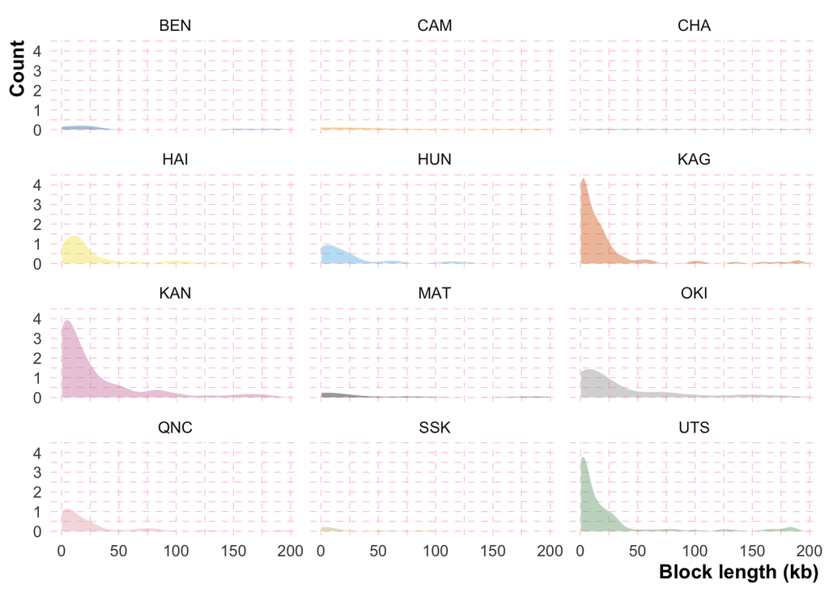

```r
# to check how many colors we need
# n_distinct(blocks$Population)

# define the color palette with 63 color blind colors
colors <-
  c("#0072B2", "#E69F00", "#009E73", "#F0E442", "#56B4E9", "#D55E00", "#CC79A7", "#000000", "#999999", "#E5A8B0", "#B5BB5E", "#5F9E6E", "#E6C9AF", "#A98D8E", "#C4B6D7", "#88CCEE", "#CC6677", "#DDCC77", "#117733", "#332288", "#44AA99", "#999933", "#CC4452", "#88B3A3", "#FFFF99", "#E69F00", "#56B4E9", "#D55E00", "#CC79A7", "#0072B2", "#009E73", "#F0E442", "#000000", "#999999", "#E5A8B0", "#B5BB5E", "#5F9E6E", "#E6C9AF", "#A98D8E", "#C4B6D7", "#88CCEE", "#CC6677", "#DDCC77", "#117733", "#332288", "#44AA99", "#999933", "#CC4452", "#88B3A3", "#FFFF99", "#E69F00", "#56B4E9", "#D55E00", "#CC79A7", "#0072B2", "#009E73", "#F0E442", "#000000", "#999999", "#E5A8B0", "#B5BB5E", "#5F9E6E", "#E6C9AF", "#A98D8E", "#C4B6D7", "#88CCEE")

# make plot using the sample y scale for all populations
ggplot(blocks, aes(x = KB)) +
  stat_density(
    aes(y = after_stat(count), fill = factor(Population)),
    linewidth = .5,
    alpha = .4,
    position = "identity"
  ) +
  scale_fill_manual(values = colors) +
  scale_x_continuous(labels = comma, name = "Block length (kb)") +
  scale_y_continuous(labels = comma, name = "Count") +
  theme(
    plot.title = element_text(hjust = 0.5, size = 18, face = "bold"),
    axis.text = element_text(size = 12),
    axis.title = element_text(size = 16, face = "bold"),
    strip.text = element_text(size = 14, face = "bold"),
    plot.background = element_rect(fill = "white"),
    panel.background = element_rect(fill = 'white', colour = 'black')
  ) +
  guides(fill = "none") +
  facet_wrap( ~ Population, ncol = 3) + my_theme()
```

```r
# save the plot as a PDF using ggsave
ggsave(
  here(
    "output",
    "populations",
    "figures",
    "block_density_y_scale_fixed_chr.pdf"
  ),
  width = 10,
  height = 10,
  units = "in"
)
```

Make plot allowing the y axis scale free

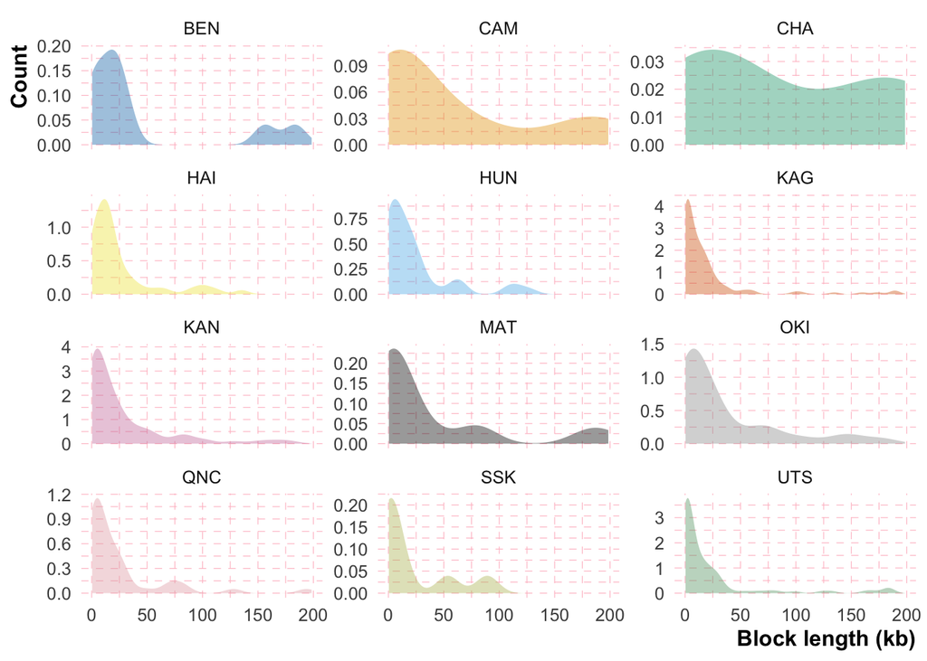

```r
ggplot(blocks, aes(x = KB)) +
  stat_density(
    aes(y = after_stat(count), fill = factor(Population)),
    linewidth = .5,
    alpha = .4,
    position = "identity"
  ) +
  scale_fill_manual(values = colors) +
  scale_x_continuous(labels = comma, name = "Block length (kb)") +
  scale_y_continuous(labels = comma, name = "Count") +
  theme(
    plot.title = element_text(hjust = 0.5, size = 18, face = "bold"),
    axis.text = element_text(size = 12),
    axis.title = element_text(size = 16, face = "bold"),
    strip.text = element_text(size = 14, face = "bold"),
    plot.background = element_rect(fill = "white"),
    panel.background = element_rect(fill = 'white', colour = 'black')
  ) +
  guides(fill = "none") +
  facet_wrap( ~ Population, ncol = 3, scales = "free_y") +
  my_theme()
```

```r
# save the plot as a PDF using ggsave
ggsave(
  here(
    "output",
    "populations",
    "figures",
    "block_density_free_scale_chr.pdf"
  ),
  width = 20,
  height = 18,
  units = "in"
)
```

# 5. SNP annotation lifting to different genome assemblies

We mapped the probe sequences to all available in NCBI and VectorBase. We can lift the annotation of the SNPs to all genomes.

## 5.1 AalbF2

Check the results of the mapping.

```bash
head output/probes/results_cluster/bwa/bwa_mem_default_results/AalbF2_ncbi.albopictus_Ref_F.txt
```

```
## Read_Name Ref_Name Start End SNP Strand Mapping_Quality Mismatches Indels
## AX-582945972_F NW_021837045 11080 11150 11115 - 60 0 0
## AX-582191512_F NW_021837045 20143 20143 20178 - 0 1 0
## AX-583160724_F NW_021837045 21036 21036 21071 - 0 0 0
## AX-582943846_F NW_021837045 22286 22356 22321 + 18 0 0
## AX-582943848_F NW_021837045 22597 22667 22632 + 60 0 0
## AX-583160720_F NW_021837045 23055 23055 23090 - 0 0 0
## AX-584286814_F NW_021837045 45905 45905 45940 + 0 6 1
## AX-582943855_F NW_021837045 78569 78639 78604 + 7 0 0
## AX-583994837_F NW_021837045 109750 109750 109785 - 0 1 0
```

We can import the data into R

Mapping results for the probe sequences with the reference allele (AalbF3)

```r
# Load the data into a data table directly using `here` in `fread`
AalbF2_ref_F <-
  fread(
    here(
      "output",
      "probes",
      "results_cluster",
      "bwa",
      "bwa_mem_default_results",
      "AalbF2_ncbi.albopictus_Ref_F.txt"
    ),
    sep = " "
  )

# Remove the "_F" from the end of the strings in the "Read_Name" column
AalbF2_ref_F$Read_Name <- sub("_F$", "", AalbF2_ref_F$Read_Name)

# Rename the "Reference" column to "SNP_id"
setnames(AalbF2_ref_F, "Read_Name", "SNP_id")

# Rename the "SNP" column to "Position"
setnames(AalbF2_ref_F, "SNP", "Position")

head(AalbF2_ref_F)
```

```
##          SNP_id     Ref_Name Start   End Position Strand Mapping_Quality
## 1: AX-582945972 NW_021837045 11080 11150    11115      -              60
## 2: AX-582191512 NW_021837045 20143 20143    20178      -               0
## 3: AX-583160724 NW_021837045 21036 21036    21071      -               0
## 4: AX-582943846 NW_021837045 22286 22356    22321      +              18
## 5: AX-582943848 NW_021837045 22597 22667    22632      +              60
## 6: AX-583160720 NW_021837045 23055 23055    23090      -               0
##    Mismatches Indels
## 1:          0      0
## 2:          1      0
## 3:          0      0
## 4:          0      0
## 5:          0      0
## 6:          0      0
```

I created a list of SNPs with unique mapping and zero mismatches. We can import it

```r
# Load the data into a data table directly using `here` in `fread`
AalbF2_ref_u <- fread(
  here(
    "output",
    "probes",
    "results_cluster",
    "bwa",
    "bwa_mem_default_results",
    "AalbF2_ncbi.albopictus_Ref_F_unique_no_mismatches_ids.txt"
  ),
  sep = " ",
  header = FALSE # Treat the first line as data
)

# Name the column as "SNP_id"
setnames(AalbF2_ref_u, "V1", "SNP_id")

# Remove the "_F" from the end of the strings in the "Read_Name" column
AalbF2_ref_u$SNP_id <- sub("_F$", "", AalbF2_ref_u$SNP_id)

head(AalbF2_ref_u)
```

```
##          SNP_id
## 1: AX-579436016
## 2: AX-579436089
## 3: AX-579436102
## 4: AX-579436125
## 5: AX-579436149
## 6: AX-579436196
```

Before we do any data tidying we can check how many probe sequences mapped with mismatches, low quality, or have indels.

```r
# Count the number of SNP_id with Mapping_Quality less than 20
count_MQ_lt_20_ref <- nrow(AalbF2_ref_F[Mapping_Quality < 20])

# Count the number of SNP_id with Mismatches greater than 0
count_MM_gt_0_ref <- nrow(AalbF2_ref_F[Mismatches > 0])

# Count the number of SNP_id with Indels greater than 0
count_IN_gt_0_ref <- nrow(AalbF2_ref_F[Indels > 0])

# Create a table of the counts of each SNP_id
SNP_id_counts_ref <- table(AalbF2_ref_F$SNP_id)

# Find which SNP_ids appear more than once and count them
SNP_id_more_than_once_ref <- length(which(SNP_id_counts_ref > 1))

# Find which SNP_ids appear exactly once and count them
SNP_id_only_once_ref <- length(which(SNP_id_counts_ref == 1))


# Print the counts
print(paste("Number of SNP_id with Mapping_Quality < 20: ", count_MQ_lt_20_ref))
```

```
## [1] "Number of SNP_id with Mapping_Quality < 20:  223561"
```

```r
print(paste("Number of SNP_id with Mismatches > 0: ", count_MM_gt_0_ref))
```

```
## [1] "Number of SNP_id with Mismatches > 0:  109614"
```

```r
print(paste("Number of SNP_id with Indels > 0: ", count_IN_gt_0_ref))
```

```
## [1] "Number of SNP_id with Indels > 0:  23311"
```

```r
print(paste("Number of SNP_id appearing more than once: ", SNP_id_more_than_once_ref))
```

```
## [1] "Number of SNP_id appearing more than once:  102442"
```

```r
print(paste("Number of SNP_id appearing only once: ", SNP_id_only_once_ref))
```

```
## [1] "Number of SNP_id appearing only once:  72954"
```

Some probe sequences mapped in more than one place. Lets filter the data by mapping quality > 20, allowing no mismatches or indels. The genome assembly AalbF2 is around 2.5Gb while the AalbF3 is around 1.5Gb. We used AalbF3 to design the probe sequences.

```r
# Filter the data based on your conditions
filtered_AalbF2_ref_F <- AalbF2_ref_F[Mapping_Quality >= 20 & Mismatches == 0 & Indels == 0]
```

Lets compare before and after filtering

```r
print(paste("Number of SNP before filtering: ", length(unique(AalbF2_ref_F$SNP_id))))
```

```
## [1] "Number of SNP before filtering:  175396"
```

```r
print(paste("Number of SNP after filtering: ", length(unique(filtered_AalbF2_ref_F$SNP_id))))
```

```
## [1] "Number of SNP after filtering:  118480"
```

Only 118,480 out of the 175,396 SNPs had unique mapping with zero mismatches or indels in the AalbF2.

We can check the output of the mapping of the probe sequence with the alternative allele. We can allow 1 mismatch since it has the alternative allele.

Merge the data tables

```r
# Perform the inner join
AalbF2_ref <- AalbF2_ref_F[AalbF2_ref_u, on = "SNP_id"]
head(AalbF2_ref)
```

```
##          SNP_id     Ref_Name    Start      End Position Strand Mapping_Quality
## 1: AX-579436016 NW_021837378 32463395 32463465 32463430      -              60
## 2: AX-579436089 NW_021837378 32462227 32462297 32462262      -              60
## 3: AX-579436102 NW_021837378 32461993 32462063 32462028      -              60
## 4: AX-579436125 NW_021837378 32461571 32461641 32461606      -              60
## 5: AX-579436149 NW_021837378 32461088 32461158 32461123      -              60
## 6: AX-579436196 NW_021837378 32460378 32460448 32460413      -              60
##    Mismatches Indels
## 1:          0      0
## 2:          0      0
## 3:          0      0
## 4:          0      0
## 5:          0      0
## 6:          0      0
```

Mapping results for the probe sequences with the alternative allele (AalbF3)

```r
# Load the data into a data table directly using `here` in `fread`
AalbF2_alt_F <-
  fread(
    here(
      "output",
      "probes",
      "results_cluster",
      "bwa",
      "bwa_mem_default_results",
      "AalbF2_ncbi.albopictus_alt_F.txt"
    ),
    sep = " "
  )


# Remove the "_F" from the end of the strings in the "Read_Name" column
AalbF2_alt_F$Read_Name <- sub("_F$", "", AalbF2_alt_F$Read_Name)

# # Create a new column "Reference" by appending "_alt" to the "Read_Name" values
# AalbF2_alt_F[, Reference := paste0(Read_Name, "_alt")]

# Rename the "Reference" column to "SNP_id"
setnames(AalbF2_alt_F, "Read_Name", "SNP_id")

# Rename the "SNP" column to "Position"
setnames(AalbF2_alt_F, "SNP", "Position")

head(AalbF2_alt_F)
```

```
##          SNP_id     Ref_Name Start   End Position Strand Mapping_Quality
## 1: AX-582945972 NW_021837045 11080 11150    11115      -              56
## 2: AX-582191512 NW_021837045 20143 20143    20178      -               0
## 3: AX-583160724 NW_021837045 21036 21036    21071      -               0
## 4: AX-582943846 NW_021837045 22286 22356    22321      +              17
## 5: AX-582943848 NW_021837045 22597 22667    22632      +              48
## 6: AX-583160720 NW_021837045 23055 23055    23090      -               0
##    Mismatches Indels
## 1:          1      0
## 2:          2      0
## 3:          1      0
## 4:          1      0
## 5:          1      0
## 6:          1      0
```

Lets filter the alt allele object

```r
# Filter the data based on your conditions
filtered_AalbF2_alt_F <- AalbF2_alt_F[Mapping_Quality >= 20 & Mismatches == 1 & Indels == 0]
```

Lets compare before and after filtering

```r
print(paste("Number of SNP before filtering: ", length(unique(AalbF2_alt_F$SNP_id))))
```

```
## [1] "Number of SNP before filtering:  175396"
```

```r
print(paste("Number of SNP after filtering: ", length(unique(filtered_AalbF2_alt_F$SNP_id))))
```

```
## [1] "Number of SNP after filtering:  108830"
```

Although we do not know for sure if the mismatch is at the SNP position, we can see that we have 108,830 probe sequences with the alternative allele mapping uniquely to AalbF2.

We can get the overlap of the SNP ids between the two objects

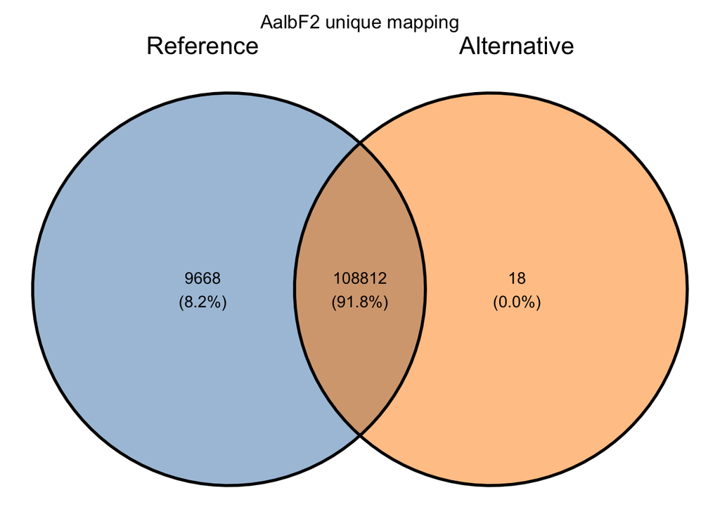

```r
# Calculate shared values
AalbF2_SNPs <- intersect(filtered_AalbF2_ref_F$SNP_id, filtered_AalbF2_alt_F$SNP_id)

library(ggvenn)
# Create Venn diagram
venn_AalbF2 <- list(
  "Reference" = filtered_AalbF2_ref_F$SNP_id,
  "Alternative" = filtered_AalbF2_alt_F$SNP_id
)
venn_plot2 <- ggvenn(venn_AalbF2, fill_color = c("steelblue", "darkorange"), show_percentage = TRUE)

# Add a title
venn_plot2 <- venn_plot2 +
  ggtitle("AalbF2 unique mapping") +
  theme(plot.title = element_text(hjust = .5))

# Display the Venn diagram
print(venn_plot2)
```

We have 108,812 SNPs that we can use with AalbF2. Before we move ahead, we can extract this SNPs from each data set and see if their coordinates match.

Lets filter the data tables to keep only the shared SNP_id

```r
# Filter the data table to keep only the rows where SNP_id is in SNP_id_vector
filtered_AalbF2_ref <- filtered_AalbF2_ref_F[SNP_id %in% AalbF2_SNPs]
filtered_AalbF2_alt <- filtered_AalbF2_alt_F[SNP_id %in% AalbF2_SNPs]
```

Now we can compare the SNP positions

```r
# Merge the data tables based on the "SNP_id" column
compare_pos <- merge(filtered_AalbF2_ref, filtered_AalbF2_alt, by = "SNP_id", suffixes = c("_ref", "_alt"))

# Create a new column to check if "Position" matches in both data tables
compare_pos[, Position_match := Position_ref == Position_alt]

# We can keep only the rows with "TRUE" on Position_match
matched_SNPs <- compare_pos[Position_match == TRUE]

# We can create a vetor with the SNP ids
SNP_id_vector <- matched_SNPs$SNP_id

# How many SNPs we have
length(SNP_id_vector)
```

```
## [1] 108812
```

All probe sequences with reference and alternative alleles mapped to the same region.

Now we can use either filtered_AalbF2_ref or filtered_AalbF2_alt to get the position of the SNPs in the AalbF2

```r
# Columns to select
AalbF2_SNP_pos <- filtered_AalbF2_ref[, .(SNP_id, Ref_Name, Position)]

# Rename the "Ref_Name" column to "Scaffold"
setnames(AalbF2_SNP_pos, "Ref_Name", "Scaffold")

# Check the first few rows of the new data table
print(head(AalbF2_SNP_pos))
```

```
##          SNP_id     Scaffold Position
## 1: AX-582945972 NW_021837045    11115
## 2: AX-582943848 NW_021837045    22632
## 3: AX-582943896 NW_021837045   133778
## 4: AX-582943915 NW_021837045   161360
## 5: AX-582943937 NW_021837045   197704
## 6: AX-582946090 NW_021837045   214418
```

Now we can check the file7.bim that we created earlier using a chromosomal scale for AalbF3

```bash
head output/populations/file7.bim
```

```
## 1    AX-583033342    0   315059  C   G
## 1    AX-583033370    0   330057  G   A
## 1    AX-583035194    0   330265  A   G
## 1    AX-583033387    0   331288  C   T
## 1    AX-583035257    0   442875  T   C
## 1    AX-583035355    0   540754  G   C
## 1    AX-583033631    0   713019  T   A
## 1    AX-583034838    0   1138155 T   C
## 1    AX-583034951    0   1155151 T   C
## 1    AX-583034959    0   1155381 C   A
```

We need to import the .bim file and merge it with the AalbF2_SNP_pos

```r
# load the function that we saved earlier
source(
  here(
    "scripts", "analysis", "import_bim.R"
  ),
  local = knitr::knit_global()
)
# import the file
file7 <- import_bim(
  here(
    "output", "populations", "file7.bim"
  )
)

# Convert to data table
setDT(file7)

# Rename columns
setnames(file7, "SNP", "SNP_id")
setnames(file7, "Scaffold", "Scaffold_AalbF3")
setnames(file7, "Position", "Position_AalbF3")

head(file7)
```

```
##    Scaffold_AalbF3       SNP_id Cm Position_AalbF3 Allele1 Allele2
## 1:               1 AX-583033342  0          315059       C       G
## 2:               1 AX-583033370  0          330057       G       A
## 3:               1 AX-583035194  0          330265       A       G
## 4:               1 AX-583033387  0          331288       C       T
## 5:               1 AX-583035257  0          442875       T       C
## 6:               1 AX-583035355  0          540754       G       C
```

Merge the data

```r
# Merge the data tables based on the "SNP_id" column
merged_data <- merge(AalbF2_SNP_pos, file7, by = "SNP_id")
head(merged_data)
```

```
##          SNP_id     Scaffold Position Scaffold_AalbF3 Cm Position_AalbF3
## 1: AX-579436149 NW_021837378 32461123               2  0       359888898
## 2: AX-579436196 NW_021837378 32460413               2  0       359889608
## 3: AX-579436243 NW_021837378 32459083               2  0       359890938
## 4: AX-579436308 NW_021837378 32455721               2  0       359894300
## 5: AX-579436317 NW_021837378 32455487               2  0       359894534
## 6: AX-579436508 NW_021837378 32450497               2  0       359899524
##    Allele1 Allele2
## 1:       A       C
## 2:       C       T
## 3:       A       G
## 4:       A       C
## 5:       G       T
## 6:       A       G
```

```r
# Select the columns we need for bim file
merged_data <-
  merged_data |>
  dplyr::select(
    Scaffold, SNP_id, Cm, Position, Allele1, Allele2
  )
# check it
head(merged_data)
```

```
##        Scaffold       SNP_id Cm Position Allele1 Allele2
## 1: NW_021837378 AX-579436149  0 32461123       A       C
## 2: NW_021837378 AX-579436196  0 32460413       C       T
## 3: NW_021837378 AX-579436243  0 32459083       A       G
## 4: NW_021837378 AX-579436308  0 32455721       A       C
## 5: NW_021837378 AX-579436317  0 32455487       G       T
## 6: NW_021837378 AX-579436508  0 32450497       A       G
```

We can save the SNP ids to file and extract it from file 7

```r
write.table(
  merged_data$SNP_id,
  file      = here(
    "output", "populations", "AalbF2_SNPs.txt"
  ),
  sep       = "\t",
  row.names = FALSE,
  col.names = FALSE,
  quote     = FALSE
)
```

Now we can create a new file

```bash
plink2 \
--bfile output/populations/file7 \
--make-bed \
--extract output/populations/AalbF2_SNPs.txt \
--allow-extra-chr \
--out output/populations/file8 \
--silent;

grep "variants" output/populations/file8.log
```

```
## 82731 variants loaded from output/populations/file7.bim.
## --extract: 44697 variants remaining.
## 44697 variants remaining after main filters.
```

Import file8.bim

```r
# Import the file with explicit column names
file8 <- fread(
  here("output", "populations", "file8.bim"),
  col.names = c("Chr_AalbF3", "SNP_id", "Cm", "Position_AalbF3", "Allele1", "Allele2")
)

head(file8)
```

```
##    Chr_AalbF3       SNP_id Cm Position_AalbF3 Allele1 Allele2
## 1:          1 AX-583033631  0          713019       T       A
## 2:          1 AX-583034838  0         1138155       T       C
## 3:          1 AX-583037044  0         1277398       G       A
## 4:          1 AX-583035342  0         1278179       T       C
## 5:          1 AX-583037429  0         1310198       T       C
## 6:          1 AX-583037492  0         1310753       T       G
```

We have to merge it again

```r
# Merge the data tables based on the "SNP_id" column
merged_data2 <- merge(AalbF2_SNP_pos, file8, by = "SNP_id")
head(merged_data2)
```

```
##          SNP_id     Scaffold Position Chr_AalbF3 Cm Position_AalbF3 Allele1
## 1: AX-579436149 NW_021837378 32461123          2  0       359888898       A
## 2: AX-579436196 NW_021837378 32460413          2  0       359889608       C
## 3: AX-579436243 NW_021837378 32459083          2  0       359890938       A
## 4: AX-579436308 NW_021837378 32455721          2  0       359894300       A
## 5: AX-579436317 NW_021837378 32455487          2  0       359894534       G
## 6: AX-579436508 NW_021837378 32450497          2  0       359899524       A
##    Allele2
## 1:       C
## 2:       T
## 3:       G
## 4:       C
## 5:       T
## 6:       G
```

```r
# Select the columns we need for the bim file
merged_data2 <-
  merged_data2 |>
  dplyr::select(
    Scaffold, SNP_id, Cm, Position, Allele1, Allele2
  )
# check it
head(merged_data2)
```

```
##        Scaffold       SNP_id Cm Position Allele1 Allele2
## 1: NW_021837378 AX-579436149  0 32461123       A       C
## 2: NW_021837378 AX-579436196  0 32460413       C       T
## 3: NW_021837378 AX-579436243  0 32459083       A       G
## 4: NW_021837378 AX-579436308  0 32455721       A       C
## 5: NW_021837378 AX-579436317  0 32455487       G       T
## 6: NW_021837378 AX-579436508  0 32450497       A       G
```

We need to set the SNP order to match the file 8 because of the encoding of the files

```r
# Merge the data and keep the order based on SNP_id in file8
merged_data_ordered <- merge(file8, merged_data2, by = "SNP_id", sort = FALSE)

# Select the columns we need for bim file
merged_data_ordered <-
  merged_data_ordered |>
  dplyr::select(
    Scaffold, SNP_id, Cm.x, Position, Allele1.x, Allele2.x
  )

# Show the first few rows of the merged data
head(merged_data_ordered)
```

```
##        Scaffold       SNP_id Cm.x Position Allele1.x Allele2.x
## 1: NW_021838798 AX-583033631    0 73277244         T         A
## 2: NW_021838798 AX-583034838    0 72852108         T         C
## 3: NW_021838798 AX-583037044    0 72712865         G         A
## 4: NW_021838798 AX-583035342    0 72712084         T         C
## 5: NW_021838798 AX-583037429    0 72680065         T         C
## 6: NW_021838798 AX-583037492    0 72679510         T         G
```

Check if the order of the SNPs match the file8.bim

```bash
head output/populations/file8.bim
```

```
## 1    AX-583033631    0   713019  T   A
## 1    AX-583034838    0   1138155 T   C
## 1    AX-583037044    0   1277398 G   A
## 1    AX-583035342    0   1278179 T   C
## 1    AX-583037429    0   1310198 T   C
## 1    AX-583037492    0   1310753 T   G
## 1    AX-583037870    0   1346607 A   G
## 1    AX-583037899    0   1346850 G   A
## 1    AX-583036374    0   1353955 T   C
## 1    AX-583036635    0   1359862 C   T
```

Save the new .bim file

```r
write.table(
  merged_data_ordered,
  file      = here(
    "output", "populations", "file8B.bim"
  ),
  sep       = "\t",
  row.names = FALSE,
  col.names = FALSE,
  quote     = FALSE
)
```

Rename the .bim files

```bash
# change the name of the first .bim file, for example, append _backup.bim, and then replace the original file
mv output/populations/file8.bim output/populations/file8_backup.bim;
# than change the new bim we create to the original name (do it only once, otherwise it will mess up)
mv output/populations/file8B.bim output/populations/file8.bim
```

```bash
plink \
--keep-allele-order \
--bfile output/populations/file8 \
--make-bed \
--allow-extra-chr \
--out output/populations/file9;
```

[output not shown]

Check the new file9.bim

```bash
head output/populations/file9.bim
```

```
## 1    AX-583033631    0   713019  T   A
## 1    AX-583034838    0   1138155 T   C
## 1    AX-583037044    0   1277398 G   A
## 1    AX-583035342    0   1278179 T   C
## 1    AX-583037429    0   1310198 T   C
## 1    AX-583037492    0   1310753 T   G
## 1    AX-583037870    0   1346607 A   G
## 1    AX-583037899    0   1346850 G   A
## 1    AX-583036374    0   1353955 T   C
## 1    AX-583036635    0   1359862 C   T
```

```r
head(AalbF2_SNP_pos)
```

```
##          SNP_id     Scaffold Position
## 1: AX-582945972 NW_021837045    11115
## 2: AX-582943848 NW_021837045    22632
## 3: AX-582943896 NW_021837045   133778
## 4: AX-582943915 NW_021837045   161360
## 5: AX-582943937 NW_021837045   197704
## 6: AX-582946090 NW_021837045   214418
```

Check a few SNPs to see if they match

```r
merged_data_ordered |>
  dplyr::filter(
    SNP_id == "AX-583787677"
  )
```

```
##        Scaffold       SNP_id Cm.x Position Allele1.x Allele2.x
## 1: NW_021838798 AX-583787677    0  1587755         A         G
```

All looks good.

Please check the manual and manuscript of Admixture. We do not need all variants to run the analysis: we opted to reduce the data set, and use cross validation and bootstrapping to find the optimal number of ancestral populations (k). We have a maximum wall time in our clusters of 5 days. Using the entire data set with cross validation and bootstrapping would require longer time for high k values. Check the R Markdown file 02.Admixture_analysis.Rmd to see how we set up the analysis. From the Admixture manual page 6:

```
As a rule of thumb, we have found that 10,000 markers suffice to perform GWAS correction for
continentally separated populations (for example, African, Asian, and European populations FST >
.05) while more like 100,000 markers are necessary when the populations are within a continent
(Europe, for instance, FST < 0.01).
```

# 6. Plot SNP density

```r
# load the function that we saved earlier
source(
  here(
    "scripts", "analysis", "import_bim.R"
  ),
  local = knitr::knit_global()
)
# import the file
snp_den_qc <- import_bim(
  here(
    "output", "populations", "file7.bim"
  )
)
```

Make plot of the SNP density

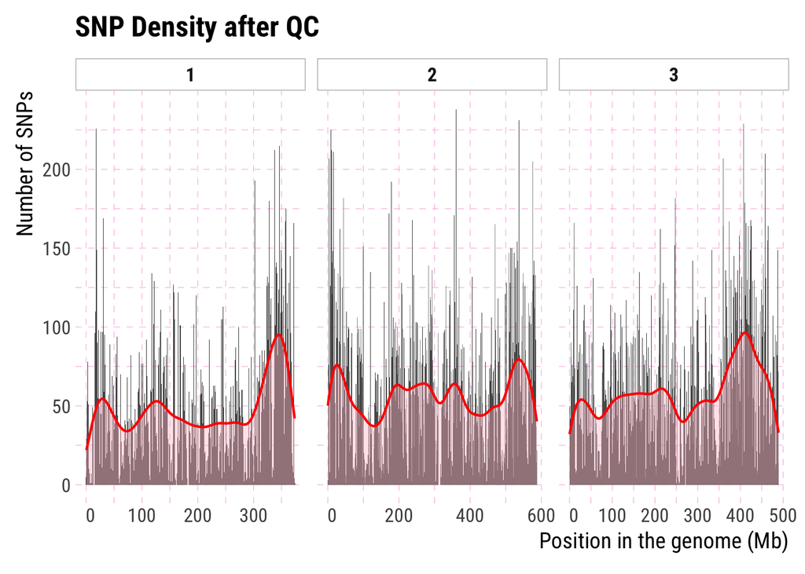

```r
#   ____________________________________________________________________________
#   plot SNP density after QC                                               ####
snp_den_qc |>
  rename(
    Chromosome = 1
  ) |>
  mutate(
    Position           = as.numeric(
      Position
    )
  ) |>
  ggplot(
    aes(
      x                = Position
    ),
    label              = sprintf(
      "%0.2f",
      round(
        a,
        digits         = 0
      )
    )
  ) +
  geom_histogram(
    aes(
      y                = after_stat(
        count
      )
    ),
    binwidth           = 1e6
  ) +
  facet_wrap(
    vars(
      Chromosome
    ),
    scales             = "free_x"
  ) +
  labs(
    title              = "SNP Density after QC",
    x                  = expression(
      "Position in the genome (Mb)"
    ),
    y                  = expression(
      "Number of SNPs"
    )
  ) +
  scale_x_continuous(
    labels             = function(x) {
      format(
        x / 1e6,
        big.mark       = ",",
        scientific     = FALSE
      )
    }
  ) +
  geom_density(
  aes(
    y = 1e6 * after_stat(count)
  ),
  color = "red",
  linewidth = .75,
  alpha = .4,
  fill = "pink"
  ) +
  hrbrthemes::theme_ipsum(
    base_family        = "Roboto Condensed",
    axis_text_size     = 12,
    axis_title_size    = 14,
    plot_margin        = margin(
      10, 10, 10, 10
    ),
    grid               = TRUE,
    grid_col           = "#fabbe2"
  ) +
  theme(
    panel.grid.major   = element_line(
      linetype         = "dashed",
      linewidth        = 0.2
    ),
    panel.grid.minor   = element_line(
      linetype         = "dashed",
      linewidth        = 0.2
    ),
    panel.spacing      = unit(0.5, "lines"),
    strip.text         = element_text(
      face             = "bold", hjust = .5
    ),
    strip.background.x = element_rect(
      color            = "gray"
    )
  )
```

```r
#   ____________________________________________________________________________
#   save the density plot                                            ####
ggsave(
  here(
    "output", "populations","figures", "snp_density_after_qc.pdf"
  ),
  width  = 10,
  height = 6,
  units  = "in"
)
```

SNPs per chromosome

```r
# we can use dplyr "count" to get the number of SNPs for each chromosome
# lets get the data we need
snps_per_chrm <-
  snp_den_qc |>
  count(
    Scaffold) |>
  rename(
    Chromosome = 1,
    "SNPs (N) " = 2
  )

# Create the flextable
ft <- flextable::flextable(snps_per_chrm)

# Apply zebra theme
ft <- flextable::theme_zebra(ft)

# Add a caption to the table
ft <- flextable::add_header_lines(ft, "SNPs per chromosome after quality control")
ft
```

| SNPs per chromosome after quality control Chromosome | SNPs per chromosome after quality control SNPs (N) |
| --- | --- |
| 1 | 18,602 |
| 2 | 34,636 |
| 3 | 29,493 |

We can get the mean number of SNPs per chromosome or the entire genome

```r
# we first use dplyr cut_width to get the number of SNPs per 1Mb window
albo_den <-
  snp_den_qc |>
  dplyr::select(
    Scaffold, Position
  ) |>
  group_by(
    Scaffold,
    windows               = cut_width(
      Position,
      width               = 1e6,
      boundary            = 0
    )
  ) |>
  summarise(
    n                     = n(),
    .groups               = "keep"
  ) |>
  group_by(
    Scaffold
  ) |>
  summarise(
    mean                  = mean(n),
    n                     = n(),
    .groups               = "keep"
  ) |>
  rename(
    Chromosome            = 1,
    "SNPs per 1Mb window" = 2,
    "Number of windows"   = 3
  )
#
# check the results
snp_table <-
  flextable(
    albo_den
  )
snp_table <- colformat_double(
  x        = snp_table,
  big.mark = ",",
  digits   = 2,
  na_str   = "N/A"
)
snp_table
```

| Chromosome | SNPs per 1Mb window | Number of windows |
| --- | --- | --- |
| 1 | 50.55 | 368 |
| 2 | 59.92 | 578 |
| 3 | 60.56 | 487 |

Merge objects

```r
# we can merge the two data sets we created above into one table
after_qc <-
  snps_per_chrm |>
  left_join(
    albo_den,
    by = "Chromosome"
  )
snp_table2 <- flextable(
  after_qc)
snp_table2 <- colformat_double(
  x        = snp_table2,
  big.mark = ",",
  digits   = 2,
  na_str   = "N/A"
  )
snp_table2
```

| Chromosome | SNPs (N) | SNPs per 1Mb window | Number of windows |
| --- | --- | --- | --- |
| 1 | 18,602 | 50.55 | 368 |
| 2 | 34,636 | 59.92 | 578 |
| 3 | 29,493 | 60.56 | 487 |

# 7. LD pruning using the chromosomal scale

```bash
# we set a window of variants of 5 and move the window 1 variant per time, removing 1 of the variants with lowest MAF from a pair above the threshold of r^2 > 0.1
# the mean distance is 203kb across the tested populations. Try --indep-pairwise 200kb 1 0.1
plink2 \
--allow-extra-chr \
--bfile output/populations/file10 \
--indep-pairwise 5 1 0.1 \
--out output/populations/indepSNP_chr \
--silent;
grep 'pairwise\|variants\|samples' output/populations/indepSNP_chr.log
```

Lets do the scaffold again

```bash
# we set a window of variants of 5 and move the window 1 variant each time, removing 1 of the variants with lowest MAF from a pair above the threshold of r^2 > 0.1
# the mean distance is 203kb across the tested populations. We used --indep-pairwise 5 1 0.1 before. We can use the same values from the mean half distance max r2
plink2 \
--allow-extra-chr \
--bfile output/populations/file11 \
--indep-pairwise 5 1 0.1 \
--out output/populations/indepSNP_scaffolds \
--silent;
grep 'pairwise\|variants\|samples' output/populations/indepSNP_scaffolds.log
```

Now we can compare the two sets of SNPs using scaffolds or chromosomal scale

Create Venn diagram of SNPs removed due to LD

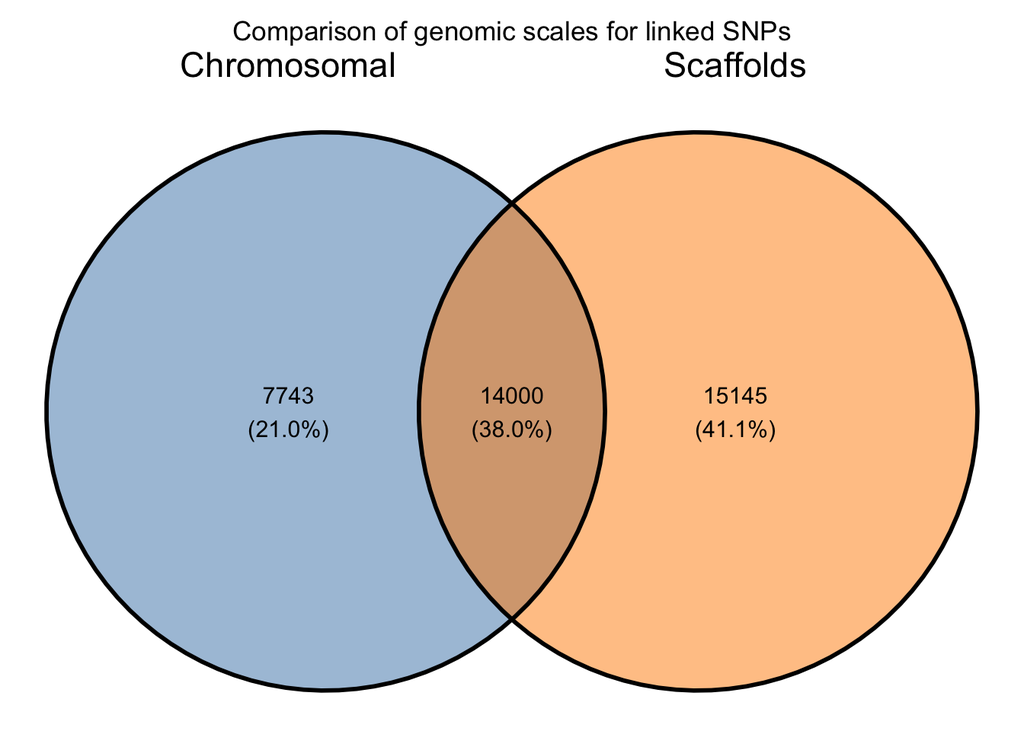

```r
# Read in the two files as vectors
prunout_chr <-
  read_delim(
    here(
      "output", "populations", "indepSNP_chr.prune.out"
    ),
    delim = " ",
    col_names = FALSE,
    show_col_types = FALSE
  )

prunout_scaffolds <-
  read_delim(
    here(
      "output", "populations", "indepSNP_scaffolds.prune.out"
    ),
    delim = " ",
    col_names = FALSE,
    show_col_types = FALSE
  )

# Convert the list to vector
prunout_scaffolds <- unlist(prunout_scaffolds)
prunout_chr <- unlist(prunout_chr)


# Calculate shared values
prunout <- intersect(prunout_chr, prunout_scaffolds)

# Create Venn diagram
venn_data1 <- list(
  "Chromosomal" = prunout_chr,
  "Scaffolds" = prunout_scaffolds
)

# create plot
venn_plot1 <- ggvenn(venn_data1, fill_color = c("steelblue", "darkorange"), show_percentage = TRUE)

# Add a title
venn_plot1 <- venn_plot1 +
  ggtitle("Comparison of genomic scales for linked SNPs") +
  theme(plot.title = element_text(hjust = .5))

# Display the Venn diagram
print(venn_plot1)
```

```r
# Save Venn diagram to PDF
output_path <- here("output", "populations", "figures", "SNPs_linked_comparison.pdf")
ggsave(output_path, venn_plot1, height = 5, width = 5, dpi = 300)
```

Create a venn diagram of SNPs kept

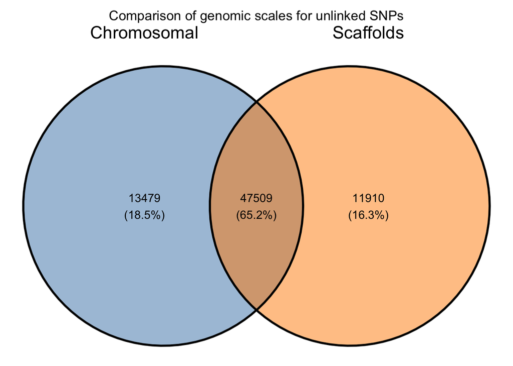

```r
# Read in the two files as vectors
prunin_chr <-
  read_delim(
    here(
      "output", "populations", "indepSNP_chr.prune.in"
    ),
    delim = " ",
    col_names = FALSE,
    show_col_types = FALSE
  )

prunin_scaffolds <-
  read_delim(
    here(
      "output", "populations", "indepSNP_scaffolds.prune.in"
    ),
    delim = " ",
    col_names = FALSE,
    show_col_types = FALSE
  )

# Convert the list to vector
prunin_chr <- unlist(prunin_chr)
prunin_scaffolds <- unlist(prunin_scaffolds)


# Calculate shared values
prunout <- intersect(prunin_chr, prunin_scaffolds)

# Create Venn diagram
venn_data2 <- list(
  "Chromosomal" = prunin_chr,
  "Scaffolds" = prunin_scaffolds
)

# create plot
venn_plot2 <- ggvenn(venn_data2, fill_color = c("steelblue", "darkorange"), show_percentage = TRUE)

# Add a title
venn_plot2 <- venn_plot2 +
  ggtitle("Comparison of genomic scales for unlinked SNPs") +
  theme(plot.title = element_text(hjust = .5))

# Display the Venn diagram
print(venn_plot2)
```

```r
# Save Venn diagram to PDF
output_path <- here("output", "populations", "figures", "SNPs_unlinked_comparison.pdf")
ggsave(output_path, venn_plot2, height = 5, width = 5, dpi = 300)
```

# 8. Intergenic unlinked SNPs

We can also create a file to run the ancestry analyses using only intergenic SNPs

We can use the intergenic SNPs as “neutral” SNPs’

```bash
plink2 \
--allow-extra-chr \
--bfile output/populations/file7 \
--geno 0.2 \
--maf 0.1 \
--make-bed \
--extract output/SnpEff/intergenic_SNPs.txt \
--out output/populations/intergenic \
--silent;
grep "samples\|variants" output/populations/intergenic.log
```

```
## 237 samples (30 females, 67 males, 140 ambiguous; 237 founders) loaded from
## 82731 variants loaded from output/populations/file7.bim.
## --extract: 11652 variants remaining.
## --geno: 0 variants removed due to missing genotype data.
## 35 variants removed due to allele frequency threshold(s)
## 11617 variants remaining after main filters.
```

Perform LD prunning

```bash
plink2 \
--allow-extra-chr \
--bfile output/populations/intergenic \
--indep-pairwise 5 1 0.1 \
--out output/populations/inter \
--silent;
grep "samples\|variants" output/populations/inter.log
```

```
## 237 samples (30 females, 67 males, 140 ambiguous; 237 founders) loaded from
## 11617 variants loaded from output/populations/intergenic.bim.
## --indep-pairwise (3 compute threads): 777/11617 variants removed.
```

Keep unlinked SNPs

```bash
plink2 \
--allow-extra-chr \
--bfile output/populations/intergenic \
--geno 0.2 \
--maf 0.1 \
--export vcf \
--make-bed \
--extract output/populations/inter.prune.in \
--out output/populations/intergenic2 \
--silent;
grep "samples\|variants" output/populations/intergenic2.log
```

```
## 237 samples (30 females, 67 males, 140 ambiguous; 237 founders) loaded from
## 11617 variants loaded from output/populations/intergenic.bim.
## --extract: 10840 variants remaining.
## --geno: 0 variants removed due to missing genotype data.
## 0 variants removed due to allele frequency threshold(s)
## 10840 variants remaining after main filters.
```

OutFLANK analysis with quasi-independent set of SNPs

We need to import the data

```r
library(OutFLANK)
library(vcfR)
```

```r
# Read your vcf file
vcf <- read.vcfR(here("output","populations","intergenic2.vcf"))
```

```
## Scanning file to determine attributes.
## File attributes:
##   meta lines: 8
##   header_line: 9
##   variant count: 10840
##   column count: 246
##
Meta line 8 read in.
## All meta lines processed.
## gt matrix initialized.
## Character matrix gt created.
##   Character matrix gt rows: 10840
##   Character matrix gt cols: 246
##   skip: 0
##   nrows: 10840
##   row_num: 0
##
Processed variant 1000
Processed variant 2000
Processed variant 3000
Processed variant 4000
Processed variant 5000
Processed variant 6000
Processed variant 7000
Processed variant 8000
Processed variant 9000
Processed variant 10000
Processed variant: 10840
## All variants processed
```

```r
# Extract genotypes
geno <- vcfR::extract.gt(vcf)

# Extract locus names (positions)
locusNames <- vcfR::getPOS(vcf)

# Samples
sampleNames <- colnames(geno)

# Extract population names by splitting the sample names
# If your sample names contain population information.
popNames <- sapply(strsplit(sampleNames, "_"), "[", 1)

# Initialize new matrix for transformed genotypes
G <- matrix(NA, nrow = nrow(geno), ncol = ncol(geno))

# Recode genotypes
G[geno %in% c("0/0", "0|0")] <- 0
G[geno %in% c("0/1", "1/0", "1|0", "0|1")] <- 1
G[geno %in% c("1/1", "1|1")] <- 2

# Replace NA with 9 for missing data
G <- replace(G, is.na(G), 9)

# Check the counts of each genotype
table(as.vector(G))
```

```
##
##       0       1       2       9
## 1299261  641241  550218   78360
```

```r
# Extract SNP names
snpNames <- vcfR::getID(vcf)

# Calculate FST with SNP names
my_fst <- MakeDiploidFSTMat(t(G), locusNames = snpNames, popNames = popNames)
```

```
## Calculating FSTs, may take a few minutes...
## [1] "10000 done of 10840"
```

```r
head(my_fst)
```

```
##      LocusName        He        FST          T1        T2  FSTNoCorr   T1NoCorr
## 1 AX-583034838 0.3574763 0.48417163 0.088444174 0.1826711 0.51657843 0.09438423
## 2 AX-583037866 0.4825236 0.29768562 0.072871445 0.2447933 0.34827829 0.08528626
## 3 AX-583038083 0.2187500 0.21973808 0.024304449 0.1106065 0.27279637 0.03018364
## 4 AX-583038481 0.3402647 0.03578489 0.006107068 0.1706605 0.08055462 0.01375156
## 5 AX-583044095 0.3597194 0.07029925 0.012725141 0.1810139 0.16476779 0.02984661
## 6 AX-583044062 0.4993328 0.14815959 0.037320744 0.2518956 0.21980594 0.05539633
##    T2NoCorr meanAlleleFreq
## 1 0.1827104      0.7669492
## 2 0.2448796      0.5934783
## 3 0.1106453      0.8750000
## 4 0.1707110      0.7826087
## 5 0.1811435      0.7648402
## 6 0.2520238      0.4817352
```

We can select the SNPs with low FST to use as neutral SNPs

```r
my_fst |>
  filter(FST<=0.20) |>
  dplyr::select(LocusName) -> neutral_snps

length(neutral_snps$LocusName)
```

```
## [1] 9483
```

```r
write.table(
  neutral_snps$LocusName,
  file = here("output", "populations", "neutral_SNPs.txt"),
  row.names = FALSE,
  quote = FALSE,
  col.names = FALSE,
  sep = "\n"
)
```

Now we can repeat the first step using the unliked SNPs with low FST values Create a vcf using the unlinked loci with no missing data

```bash
plink2 \
--allow-extra-chr \
--bfile output/populations/intergenic \
--export vcf \
--make-bed \
--extract output/populations/neutral_SNPs.txt \
--out output/populations/neutral \
--silent;
grep "samples\|variants" output/populations/neutral.log
```

```
## 237 samples (30 females, 67 males, 140 ambiguous; 237 founders) loaded from
## 11617 variants loaded from output/populations/intergenic.bim.
## --extract: 9483 variants remaining.
## 9483 variants remaining after main filters.
```

Move to dir

```bash
cp output/populations/neutral.bed output/populations/snps_sets;
cp output/populations/neutral.bim output/populations/snps_sets;
cp output/populations/neutral.fam output/populations/snps_sets;
cp output/populations/neutral.log output/populations/snps_sets;
cp output/populations/neutral.vcf output/populations/snps_sets;
ls output/populations/snps_sets
```

```
## neutral.bed
## neutral.bim
## neutral.fam
## neutral.geno
## neutral.lfmm
## neutral.log
## neutral.pca
## neutral.removed
## neutral.snmf
## neutral.snmfProject
## neutral.vcf
## neutral.vcfsnp
## r2_0.01.bed
## r2_0.01.bim
## r2_0.01.fam
## r2_0.01.geno
## r2_0.01.lfmm
## r2_0.01.log
## r2_0.01.nosex
## r2_0.01.pca
## r2_0.01.removed
## r2_0.01.snmf
## r2_0.01.snmfProject
## r2_0.01.vcf
## r2_0.01.vcfsnp
## r2_0.1.bed
## r2_0.1.bim
## r2_0.1.fam
## r2_0.1.geno
## r2_0.1.lfmm
## r2_0.1.log
## r2_0.1.nosex
## r2_0.1.pca
## r2_0.1.removed
## r2_0.1.snmf
## r2_0.1.snmfProject
## r2_0.1.vcf
## r2_0.1.vcfsnp
```

Import the data.

```r
# Read your vcf file
vcf <- read.vcfR(here("output","local_adaptation","neutral.vcf"))
```

[output not shown]

```r
# Extract genotypes
geno <- vcfR::extract.gt(vcf)

# Extract locus names (positions)
locusNames <- vcfR::getPOS(vcf)

# Samples
sampleNames <- colnames(geno)

# Extract population names by splitting the sample names
# If your sample names contain population information.
popNames <- sapply(strsplit(sampleNames, "_"), "[", 1)

# Initialize new matrix for transformed genotypes
G <- matrix(NA, nrow = nrow(geno), ncol = ncol(geno))

# Recode genotypes
G[geno %in% c("0/0", "0|0")] <- 0
G[geno %in% c("0/1", "1/0", "1|0", "0|1")] <- 1
G[geno %in% c("1/1", "1|1")] <- 2

# Check the counts of each genotype
table(as.vector(G))
```

```
##
##     0     1     2
## 64251 49967 30962
```

```r
# Extract SNP names
snpNames <- vcfR::getID(vcf)

# Calculate FST with SNP names
my_fst <- MakeDiploidFSTMat(t(G), locusNames = snpNames, popNames = popNames)
```

```
## Calculating FSTs, may take a few minutes...
```

```r
head(my_fst)
```

```
##      LocusName        He         FST          T1        T2  FSTNoCorr
## 1 AX-583034838 0.4008192 0.164885011 0.033709186 0.2044406 0.19706911
## 2 AX-583049532 0.3169621 0.019158983 0.003051440 0.1592694 0.04948776
## 3 AX-583056767 0.3415013 0.047884271 0.008249681 0.1722837 0.08895758
## 4 AX-583061613 0.3415013 0.009390761 0.001611444 0.1715989 0.04942826
## 5 AX-583061163 0.3642751 0.074842092 0.013795884 0.1843332 0.11906870
## 6 AX-583061282 0.2327519 0.138246271 0.016434909 0.1188814 0.21066659
##      T1NoCorr  T2NoCorr meanAlleleFreq
## 1 0.040289013 0.2044410      0.2773109
## 2 0.007881903 0.1592697      0.8025210
## 3 0.015325988 0.1722842      0.2184874
## 4 0.008481858 0.1715994      0.2184874
## 5 0.021948386 0.1843338      0.7605042
## 6 0.025044465 0.1188820      0.1344538
```

Data prep: decide which SNPs to use for calibrating the null distribution of Fst

```r
# Run OutFLANK to estimate the neutral FST distribution
out_trim <- OutFLANK(FstDataFrame = my_fst, Hmin = 0.1, NumberOfSamples = 10, qthreshold = 0.05)
str(out_trim)
```

```
## List of 6
##  $ FSTbar               : num 0.055
##  $ FSTNoCorrbar         : num 0.0978
##  $ dfInferred           : num 8.67
##  $ numberLowFstOutliers : int 0
##  $ numberHighFstOutliers: int 0
##  $ results              :'data.frame':   1220 obs. of  15 variables:
##   ..$ LocusName       : chr [1:1220] "AX-583034838" "AX-583049532" "AX-583056767" "AX-583061613" ...
##   ..$ He              : num [1:1220] 0.401 0.317 0.342 0.342 0.364 ...
##   ..$ FST             : num [1:1220] 0.16489 0.01916 0.04788 0.00939 0.07484 ...
##   ..$ T1              : num [1:1220] 0.03371 0.00305 0.00825 0.00161 0.0138 ...
##   ..$ T2              : num [1:1220] 0.204 0.159 0.172 0.172 0.184 ...
##   ..$ FSTNoCorr       : num [1:1220] 0.1971 0.0495 0.089 0.0494 0.1191 ...
##   ..$ T1NoCorr        : num [1:1220] 0.04029 0.00788 0.01533 0.00848 0.02195 ...
##   ..$ T2NoCorr        : num [1:1220] 0.204 0.159 0.172 0.172 0.184 ...
##   ..$ meanAlleleFreq  : num [1:1220] 0.277 0.803 0.218 0.218 0.761 ...
##   ..$ indexOrder      : int [1:1220] 1 2 3 4 5 6 7 8 9 10 ...
##   ..$ GoodH           : chr [1:1220] "goodH" "goodH" "goodH" "goodH" ...
##   ..$ qvalues         : num [1:1220] 0.838 0.982 0.971 0.982 0.971 ...
##   ..$ pvalues         : num [1:1220] 0.0716 0.2688 0.9742 0.2679 0.5608 ...
##   ..$ pvaluesRightTail: num [1:1220] 0.0358 0.8656 0.5129 0.866 0.2804 ...
##   ..$ OutlierFlag     : logi [1:1220] FALSE FALSE FALSE FALSE FALSE FALSE ...
```

Check the fit and make sure it looks good, especially in the right tail:

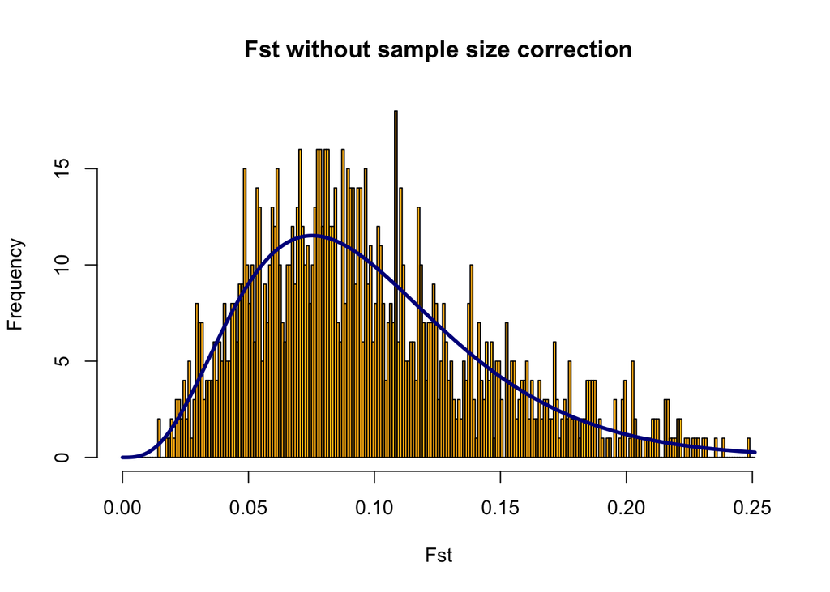

```r
OutFLANKResultsPlotter(
  out_trim,
  withOutliers = TRUE,
  NoCorr = TRUE,
  Hmin = 0.1,
  binwidth = 0.001,
  Zoom = FALSE,
  RightZoomFraction = 0.05,
  titletext = NULL
)
```

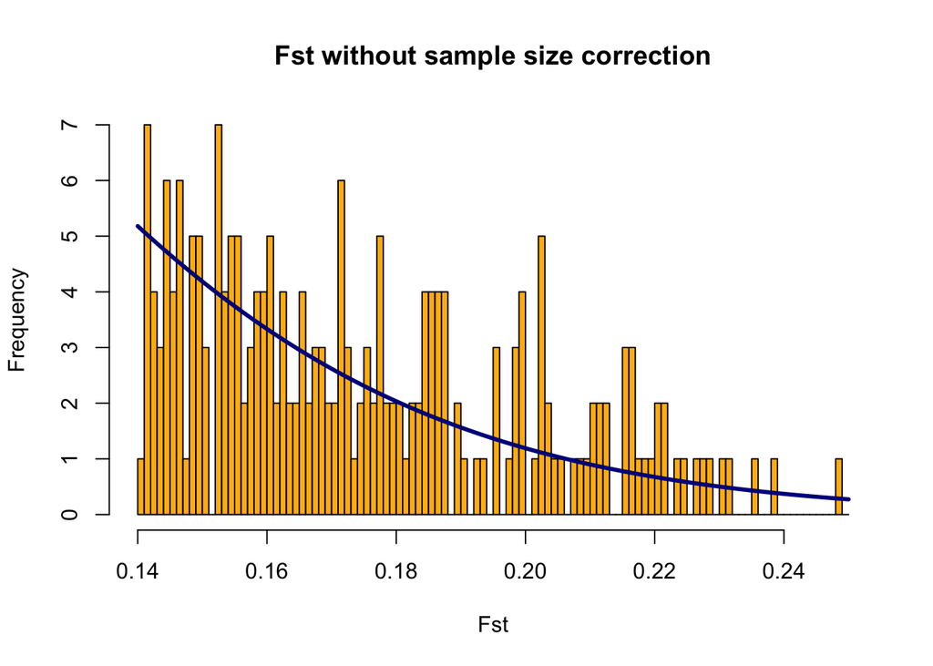

```r
## Zoom in on right tail
OutFLANKResultsPlotter(
  out_trim ,
  withOutliers = TRUE,
  NoCorr = TRUE,
  Hmin = 0.1,
  binwidth = 0.001,
  Zoom =
    TRUE,
  RightZoomFraction = 0.15,
  titletext = NULL
)
```

Also check the P-value histogram: Here, we plot the “right-tailed” P-values, which means that outliers in the right tail of the FST distribution will have a P-value near zero. Because we ran the algorithm on a trimmed set of SNPs, this will remove some of the signal around selected sites. So we expect this histogram to be flat and maybe have a bump near 0 for selected sites. This histogram looks pretty good.

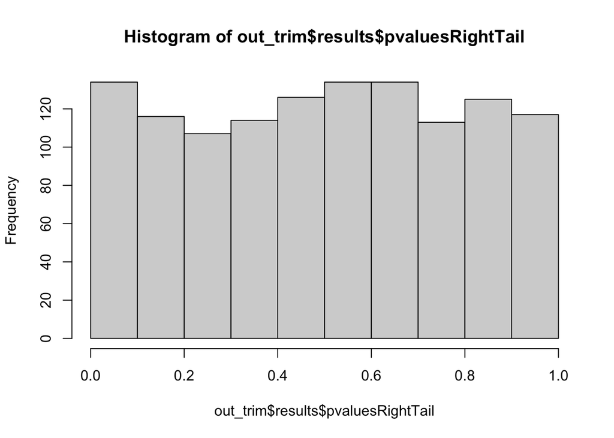

```r
hist(out_trim$results$pvaluesRightTail)
```

# 9. Pruning r2 0.01

We can use the SNP set from neuro-admixture training. We will extract it from file7

```bash
plink \
--keep-allele-order \
--bfile output/populations/file7 \
--make-bed \
--export vcf \
--out output/populations/snps_sets/r2_0.01 \
--extract output/populations/nadmix/train/train_r_0.01.snplist \
--silent
grep "variants\|samples" output/populations/snps_sets/r2_0.01.log
```

```
## 82731 variants loaded from .bim file.
## --extract: 21095 variants remaining.
## 21095 variants and 237 people pass filters and QC.
```

# 10. Pruning r2 0.1

We can use the SNP set from neuro-admixture training. We will extract it from file7

```bash
# we use the same snps that we use with neuro admxiture
plink \
--keep-allele-order \
--bfile output/populations/file7 \
--make-bed \
--export vcf \
--out output/populations/snps_sets/r2_0.1 \
--extract output/populations/nadmix/train/train_r_0.1.snplist \
--silent
grep "variants\|samples" output/populations/snps_sets/r2_0.1.log
```

```
## 82731 variants loaded from .bim file.
## --extract: 58152 variants remaining.
## 58152 variants and 237 people pass filters and QC.
```